# Probability and Statistics

# Lab Assignment 1: Naive Bayes Classifier

### *Volodymyr Kuzma, Anton Mazuryk, Oleksii Mytnyk*

## Introduction

**Naive Bayes classifier** is a probabilistic classifier whose aim is to determine which class some observation probably belongs to by using the Bayes formula:
$$\mathsf{P}(\mathrm{class}\mid
\mathrm{observation})=\frac{\mathsf{P}(\mathrm{observation}\mid\mathrm{class})\mathsf{P}(\mathrm{class})}{\mathsf{P}(\mathrm{observation})}$$

Under the strong independence assumption, one can calculate $\mathsf{P}(\mathrm{observation} \mid \mathrm{class})$ as
$$\qquad
\mathsf{P}(\mathrm{observation} \mid \mathrm{class}) = \prod_{i=1}^{n}
\mathsf{P}(\mathrm{feature}_i \mid \mathrm{class}),$$
where $n$ is the total number of features describing a given observation. Thus, $\mathsf{P}(\mathrm{class}\mid\mathrm{observation})$ now can be calculated as

$$\mathsf{P}(\mathrm{class} \mid
\mathrm{\mathrm{observation}}) = \mathsf{P}(\mathrm{class})\times
\prod_{i=1}^{n}\frac{\mathsf{P}(\mathrm{feature}_i\mid
\mathrm{class})}{\mathsf{P}(\mathrm{feature}_i)}$$
Since $\mathsf{P}(\mathrm{observation})$ does not depend on class(spam or ham) we can just compare the values of $\mathsf{P}(\mathrm{spam} \mid \mathrm{message})\cdot\mathsf{P}(\mathrm{spam})$ and $\mathsf{P}(\mathrm{ham} \mid \mathrm{message})\cdot\mathsf{P}(\mathrm{ham})$ without calculating $\mathsf{P}(\mathrm{observation})$

In other words - comparing $\mathsf{P}(\mathrm{spam})\cdot\prod_{i=1}^{n} \mathsf{P}(\mathrm{word}_i \mid \mathrm{spam})$ and $\mathsf{P}(\mathrm{ham})\cdot\prod_{i=1}^{n} \mathsf{P}(\mathrm{word}_i \mid \mathrm{ham})$

**Necessary libraries**

```r
library(tidytext)
library(readr)
library(dplyr)
```

```r
library(ggplot2)
library(wordcloud)
```

### Data pre-processing

```r
list.files(getwd()) # Should print "bayes_classifier.Rmd" "data" "README.md"
```

```
## [1] "bayes_classifier.html"  "bayes_classifier.Rmd"   "bayes_classifier_files"
## [4] "data"                   "README.md"
```

```r
list.files("data")  # Should print "stop_words.txt" "test.csv" "train.csv"
```

```
## [1] "stop_words.txt" "test.csv"       "train.csv"
```

```r
test_path <- "data/test.csv"
train_path <- "data/train.csv"

stop_words <- strsplit(read_file("data/stop_words.txt"), split='\n')[[1]]
```

#### Fetching data from csv

```r
train <- read.csv(file = train_path, stringsAsFactors = FALSE)
test  <- read.csv(file = test_path,  stringsAsFactors = FALSE)
```

#### Filtering

```r
tidy_text <- train %>% mutate(ID = row_number()) %>% unnest_tokens('Word', 'Message', token="words") %>% filter(!Word %in% stop_words)
```

#### **Final train data**

```r
X_train <- tidy_text %>% select(Word, ID)
Y_train <- (tidy_text$Category == "spam") %>% ifelse(1, 0)
```

## Data visualization

**Common spam words:**

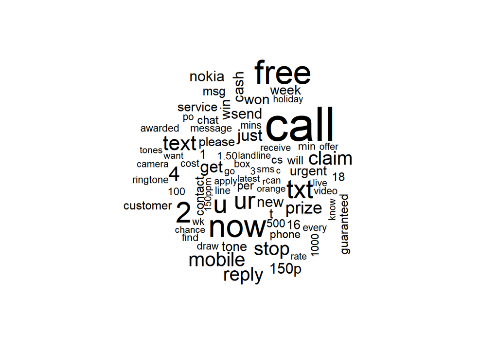

```r
count_df <- tidy_text %>% filter(Category == "spam") %>% count(Word)
wordcloud(words = count_df$Word, freq = count_df$n, max.words = 80)
```

**Common ham words:**

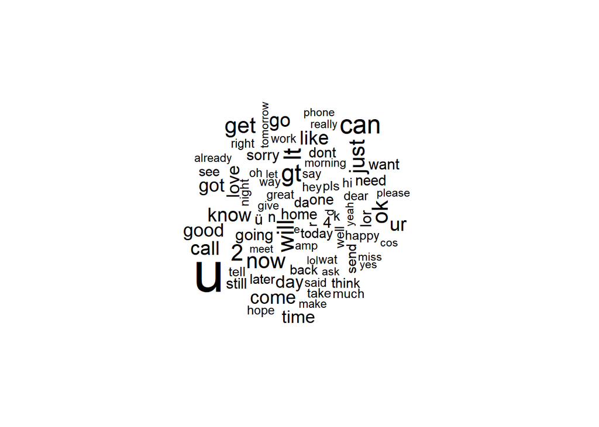

```r
count_df <- tidy_text %>% filter(Category == "ham") %>% count(Word)
wordcloud(words = count_df$Word, freq = count_df$n, max.words = 80)
```

## Classifier implementation

```r
naiveBayes <- setRefClass("naiveBayes",
  fields = list(
    spam_messages_cnt="number",
    ham_messages_cnt="number",
    spam_words_cnt="number",
    ham_words_cnt="number",
    words="data.frame"
    ),
  methods = list(
    fit = function(X, y)
    {
      df <- data.frame(X, y)
      spam_messages_cnt <<- sum((df[!duplicated(df$ID), ])$y == 1)
      ham_messages_cnt <<- sum((df[!duplicated(df$ID), ])$y == 0)
      words <<- df %>% group_by(Word) %>% transmute(
        Ham = sum(1 - y), Spam = sum(y))
      words <<- words[!duplicated(words$Word), ]
      spam_words_cnt <<- sum(words$Spam)
      ham_words_cnt <<- sum(words$Ham)
    },

    predict = function(message, threshold = 0.5)
    {
      message <- tibble('Message' = message) %>%
                  unnest_tokens('Word', 'Message', token="words") %>%
                  filter(!Word %in% stop_words) %>%
                  merge(words, by = "Word", all.x = TRUE)
      message[is.na(message)] = 0

      probability <- message %>% transmute(
        pspam = (Spam + 1) / (nrow(words) + spam_words_cnt),
        pham = (Ham + 1) / (nrow(words) + ham_words_cnt))

      # In the end, we simplify the probabilities through removing denominators as they are the same
      # The below inequality means that normalized (meaning p_spam/(p_spam + p_ham)) chance
      # of message being spam is greater than the threshold:
      # p_spam/(p_spam + p_ham) > k -> p_spam*(1-k) > p_ham*k -> p_spam > (k/(1-k))*p_ham

      return (prod(probability$pspam) * spam_messages_cnt >
              (threshold / (1 - threshold)) * prod(probability$pham) * ham_messages_cnt)
    },

    score = function(X_test, y_test, threshold = 0.5)
    {
      data <- data.frame(
        X_test %>% group_by(Message) %>% transmute(Predicted=predict(Message, threshold)),
        y_test %>% transmute(Actual = ifelse(Category == "spam", TRUE, FALSE)))

      tp <- nrow(data[data$Predicted == TRUE & data$Actual == TRUE,])
      tn <- nrow(data[data$Predicted == FALSE & data$Actual == FALSE,])
      fp <- nrow(data[data$Predicted == FALSE & data$Actual == TRUE,])
      fn <- nrow(data[data$Predicted == TRUE & data$Actual == FALSE,])
      precision <- tp / (tp + fp)
      recall <- tp / (tp + fn)
      f1 <- (2 * precision * recall / (precision + recall))

      return (list(f1, precision, recall))
    }
))

model <- naiveBayes()
model$fit(X_train, Y_train)
f1_score = model$score(test["Message"], test["Category"])[1]
```

## Effectiveness of the implemented classifier

### F1 score

Calculated for a threshold of 0.5. It is a harmonic mean of precision and recall, so its high value corresponds to the high value of both parameters (it can also be seen on the recall-precision curve), meaning that the classifier has a low rate of both incorrect positive and negative predictions

```r
f1_score
```

```
## [[1]]
## [1] 0.9207317
```

### Data receiving for plots and lists of failures

(lasts nearly 3 minutes and is unnecessary if the variables are already saved)

```r
x <- seq(0.05, 0.95, length = 19)
x <- append(x, seq(0.0025, 0.01, length = 4))

y <- sapply(x, model$score, X_test = test["Message"], y_test = test["Category"])

Precision <- y[2,]
Recall <- y[3,]


data <- data.frame(
        test["Message"] %>% group_by(Message) %>% transmute(Predicted = model$predict(Message, threshold = 0.5)),
        test["Category"] %>% transmute(Actual = ifelse(Category == "spam", TRUE, FALSE)))
```

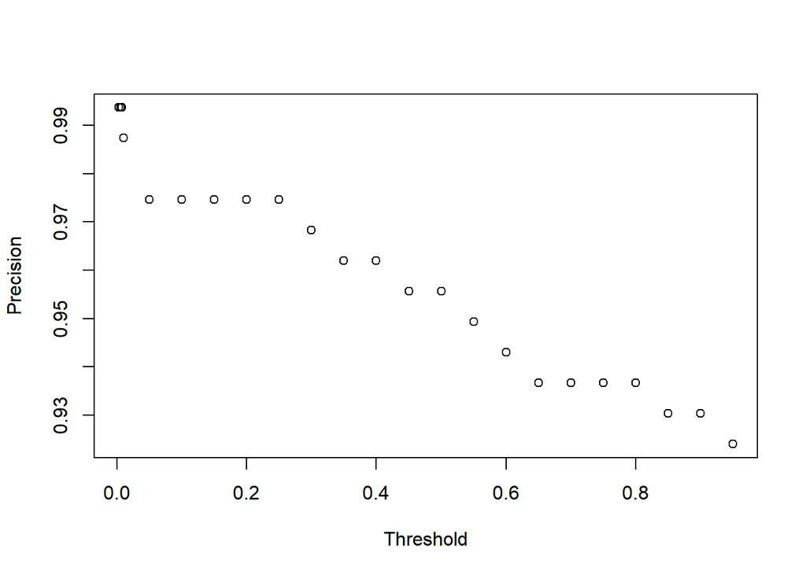

```r
plot(x, Precision, xlab = "Threshold", ylab = "Precision")
```

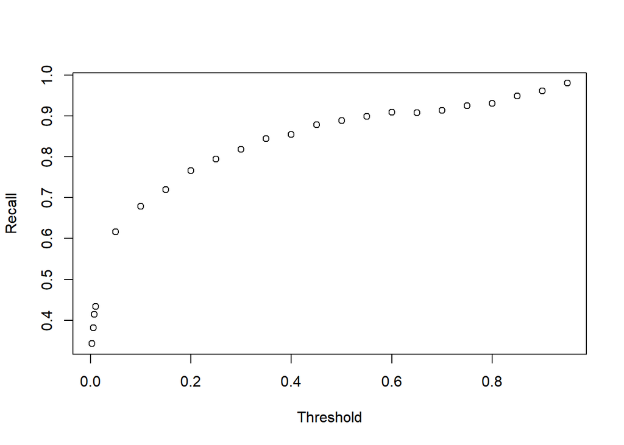

```r
plot(x, Recall, xlab = "Threshold", ylab = "Recall")
```

### Precision-recall curve

Both recall and precision have high values.

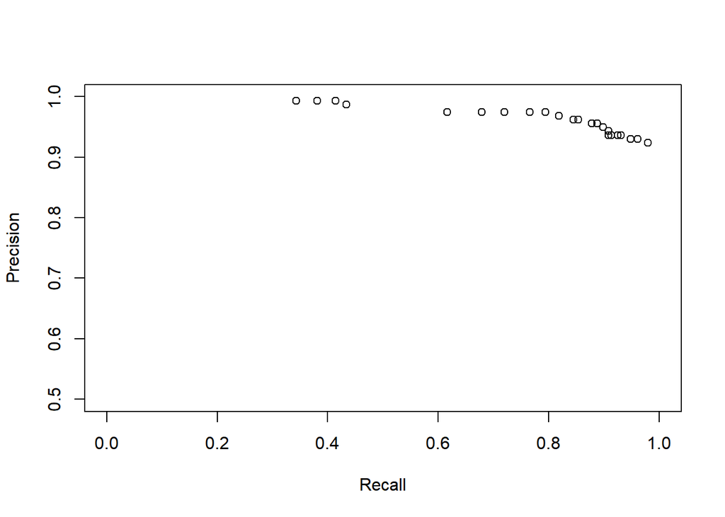

```r
plot(Recall, Precision, xlab = "Recall", ylab = "Precision", ylim = c(0.5,1), xlim = c(0,1))
```

### False negative cases

```r
data[data$Predicted == FALSE & data$Actual == TRUE, "Message"]
```

```
## [1] "Cashbin.co.uk (Get lots of cash this weekend!) www.cashbin.co.uk Dear Welcome to the weekend We have got our biggest and best EVER cash give away!! These.."
## [2] "Check Out Choose Your Babe Videos @ sms.shsex.netUN fgkslpoPW fgkslpo"
## [3] "Hi this is Amy, we will be sending you a free phone number in a couple of days, which will give you an access to all the adult parties..."
## [4] "You can donate £2.50 to UNICEF's Asian Tsunami disaster support fund by texting DONATE to 864233. £2.50 will be added to your next bill"
## [5] "dating:i have had two of these. Only started after i sent a text to talk sport radio last week. Any connection do you think or coincidence?"
## [6] "Santa Calling! Would your little ones like a call from Santa Xmas eve? Call 09058094583 to book your time."
## [7] "Latest News! Police station toilet stolen, cops have nothing to go on!"
```

### False positive cases

```r
data[data$Predicted == TRUE & data$Actual == FALSE, "Message"]
```

```
##  [1] "Mathews or tait or edwards or anderson"
##  [2] "When you get free, call me"
##  [3] "Urgh, coach hot, smells of chip fat! Thanks again, especially for the duvet (not a predictive text word)."
##  [4] "Gettin rdy to ship comp"
##  [5] "CHA QUITEAMUZING THAT\u0092SCOOL BABE,PROBPOP IN & CU SATTHEN HUNNY 4BREKKIE! LOVE JEN XXX. PSXTRA LRG PORTIONS 4 ME PLEASE "
##  [6] "Have you laid your airtel line to rest?"
##  [7] "You call him and tell now infront of them. Call him now."
##  [8] "Wewa is 130. Iriver 255. All 128 mb."
##  [9] "I liked the new mobile"
## [10] "Anytime..."
## [11] "Call me, i am senthil from hsbc."
## [12] "S.this will increase the chance of winning."
## [13] "Nokia phone is lovly.."
## [14] "My mobile number.pls sms ur mail id.convey regards to achan,amma.Rakhesh.Qatar"
## [15] "We have sent JD for Customer Service cum Accounts Executive to ur mail id, For details contact us"
## [16] "Hi Shanil,Rakhesh here.thanks,i have exchanged the uncut diamond stuff.leaving back. Excellent service by Dino and Prem."
## [17] "Aslamalaikkum....insha allah tohar beeen muht albi mufti mahfuuz...meaning same here...."
## [18] "Garbage bags, eggs, jam, bread, hannaford wheat chex"
## [19] "Dhoni have luck to win some big title.so we will win:)"
```

## Conclusions

- **Describe the method implemented in general. Show what are mathematical foundations you are basing your solution on**. The method is quite simple: we use the Bayes’ theorem to find the probability that message belongs to a certain class (spam) by calculating the chance of the message appearing if the class is already known. The mathematical foundation is (as it was already said) the Bayes’ theorem, on which we base the main “predict” function, and the Laplace smoothing, used to prevent errors due to the possible zero-probabilities. There are also several smaller tricks such as (1) reducing the fraction of the probability to the terms which are different in spam_probability and non-spam_probability, as we need it only for comparison and (2) proportionally increasing the chances for their sum to become 1 to be able to use a threshold coefficient.
- **List pros and cons of the method. This should include the limitations of your method, all the assumption you make about the nature of your data etc.** The main advantages of the method are its simplicity and sufficient accuracy (which depends on the data set but may be high as shown above). The biggest assumption (and the disadvantage that it creates) is the assumption of independence of separate words belonging to the message. It means that we assume that the words do not build logical connections that make the chance of belonging to the class higher, which is obviously not correct, yet due to the existence of common spam topics, each word with its independent from the context meaning has a significant chance of being located in such a topic. A big limitation is that the classifier needs a balanced data set. The imbalanced one will lead to good accuracy on this exact data set (its testing part) yet quite low recall and precision rates which are much more important when it is expected to be able to analyze fresh data from another source.